# Project: No-show appointments

#### 4. Gender and age

```python
# Analysing the mean age
df.age[noshowup].mean()
```

```
34.31591917200591
```

```python
# Getting the descriptive statistics of age
df.age[noshowup].describe()
```

```
count    22319.000000
mean        34.315919
std         21.960038
min          0.000000
25%         16.000000
50%         33.000000
75%         51.000000
max        102.000000
Name: age, dtype: float64
```

```python
# Getting the descriptive statistics of gender
df.gender[noshowup].describe()
```

```
count     22319
unique        2
top           F
freq      14594
Name: gender, dtype: object
```

```python
# Getting the descriptive statistics of age categories
df.age_cat[noshowup].describe()
```

```
count     22319
unique        5
top       Adult
freq      13906
Name: age_cat, dtype: object
```

```python
# Calculating the number of patients per gender
gender_no_show = df_no_show.groupby('gender').no_show.value_counts()
```

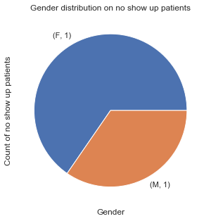

```python
# Visualising the distribution of gender
gender_no_show.plot.pie(figsize=(5,5),title = 'Gender distribution on no show up patients')
plt.xlabel("Gender")
plt.ylabel("Count of no show up patients")
plt.show();
```

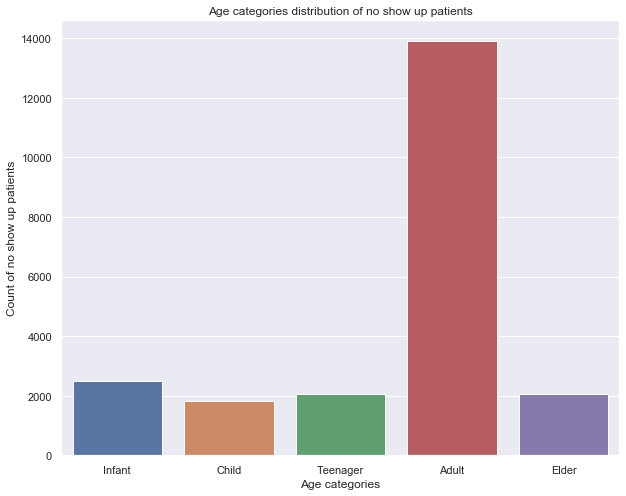

```python
# Visualising the distribution of age category
groups = df_no_show.groupby(['age_cat'])
gps = groups.size()
sns.barplot(x=gps.index.tolist(), y=gps.values)
plt.title("Age categories distribution of no show up patients")
plt.xlabel("Age categories")
plt.ylabel("Count of no show up patients")
plt.rcParams["figure.figsize"] = (10, 8)
plt.show();
```

```python
# Analysing the age categories of the patients that show up with gender
a_g_no_show = df_no_show.groupby('age_cat').gender.value_counts()
a_g_no_show
```

```
age_cat   gender
Infant    M         1285
          F         1216
Child     M          972
          F          834
Teenager  F         1260
          M          780
Adult     F         9886
          M         4020
Elder     F         1398
          M          668
Name: gender, dtype: int64
```

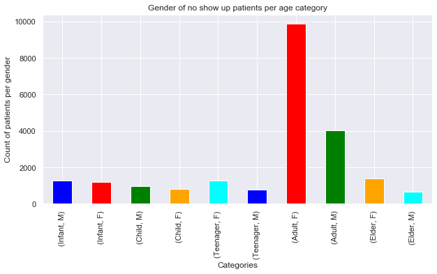

```python
age_gender_n_s = a_g_no_show.plot(kind='bar',figsize=(10,5),
                             title = 'Gender of no show up patients per age category',
                            color=['blue', 'red', 'green', 'orange', 'cyan'])
age_gender_n_s.set(xlabel="Categories", ylabel="Count of patients per gender");
```

#### 5. Duplicate patient appointment / Unique patient appointment

```python
# Mean of the variable
df.patient_duplicated[noshowup].mean()
```

```
0.45369416192481743
```

```python
# Descriptive statistics of the variable
df.patient_duplicated[noshowup].describe()
```

```
count    22319.000000
mean         0.453694
std          0.497862
min          0.000000
25%          0.000000
50%          0.000000
75%          1.000000
max          1.000000
Name: patient_duplicated, dtype: float64
```

```python
# Counts of same patient with multiple appointments
df_no_show.patient_duplicated[patientduplicated].value_counts()
```

```
1    10126
Name: patient_duplicated, dtype: int64
```

```python
# Counts of same patient with one appointments
df_no_show.patient_duplicated[patientunique].value_counts()
```

```
0    12193
Name: patient_duplicated, dtype: int64
```

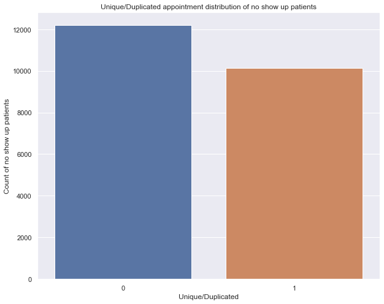

```python
# Visualising distribution of duplicated patients
groups = df_no_show.groupby(['patient_duplicated'])
gps = groups.size()
sns.barplot(x=gps.index.tolist(), y=gps.values)
plt.title("Unique/Duplicated appointment distribution of no show up patients")
plt.xlabel("Unique/Duplicated")
plt.ylabel("Count of no show up patients")
plt.rcParams["figure.figsize"] = (10, 8)
plt.show()
```

```python
# Analysing the age categories of the patients that no show up with unique/duplicated appointment
a_pd_no_show = df_no_show.groupby('age_cat').patient_duplicated.value_counts()
a_pd_no_show
```

```
age_cat   patient_duplicated
Infant    0                     1528
          1                      973
Child     0                      977
          1                      829
Teenager  0                     1039
          1                     1001
Adult     0                     7554
          1                     6352
Elder     0                     1095
          1                      971
Name: patient_duplicated, dtype: int64
```

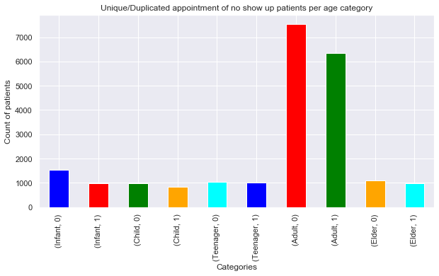

```python
# Showing distribution
a_pd_no_show = a_pd_no_show.plot(kind='bar',figsize=(10,5),
                             title = 'Unique/Duplicated appointment of no show up patients per age category',
                            color=['blue', 'red', 'green', 'orange', 'cyan'])
a_pd_no_show.set(xlabel="Categories", ylabel="Count of patients");
```

```python
df_no_show.waiting_days[patientduplicated].mean(), df_no_show.waiting_days[patientunique].mean()
```

```
(13.166502073869248, 16.36324120396949)
```

```python
# Analysing the waiting days categories of the patients that show up with unique/duplicated appointment
w_pd_no_show = df_no_show.groupby('waiting_cat').patient_duplicated.value_counts()
w_pd_no_show
```

```
waiting_cat        patient_duplicated
immediate: 0       1                     1629
                   0                     1276
one_week: 1-7      0                     3858
                   1                     3476
one_month: 8-30    0                     5022
                   1                     3853
trimester: 31-90   0                     2007
                   1                     1154
half_year: 91-180  0                       30
                   1                       14
Name: patient_duplicated, dtype: int64
```

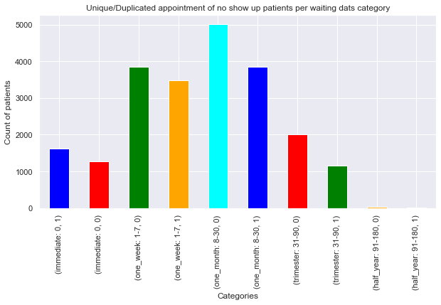

```python
# Showing distribution
w_pd_no_show = w_pd_no_show.plot(kind='bar',figsize=(10,5),
                             title = 'Unique/Duplicated appointment of no show up patients per waiting dats category',
                            color=['blue', 'red', 'green', 'orange', 'cyan'])
w_pd_no_show.set(xlabel="Categories", ylabel="Count of patients");
```

> In the case of no show up patients, there are slithly more cases with one appointment, although they wait more days (16 days versus 13 days with more than one appointment) Besides, we can see that there is a high number of patients with more than one appointmet within the first week and one month.

## Conclusions

> This project aims to analyse the characteristics of the dataset to understand which variables affect a patient to show or not show up in their medical appointment.

> There is no correlation evident between variables, for this reason, we carried an analysis of the properties of each independent variable in relation with showing or not showing.

> Besides, it is interesting to note that the neighbourhood with more scholarships, in both samples, is Ilha do Príncipe. Finally, add to this point, that only one neighboorhood with scholarship in the patients showing up is also part of the top 5: Resistencia.

> Next, analysing the diseases and the SMS reception, both groups present high cases of patients with hypertension (especially for patients showing up), and only patients showing up have a high number patients with diabetes. Apart from that, receiving SMS in both cases present an elevated number.

> The following section enlights that there is a higher chance of patients showing up when the appointment is rather immediate, whereas they will not show up if they have to wait between one week and one month.

> Looking at gender and age, for both situations, adults and women are more predisposed to either show or not show. Hence, doing inferential theories based on gender and age is not advised.

> Ultimately, there are more patients with a unique appointment, however, in both cases, the waiting time is higher than when the patient has multiple appointments.

> All in all, those characteristics that are present in both categories can be discarded as factors that will make a patient more prone to show or not show up. The only differences could be that patients with diabetes are more prone to do not miss their appointment and that the extended waiting time, the likely to miss it.

> Limitations that we found:

> ```
> - the data type boolean makes correlation more difficult to check;
> - besides, there is a clear uncertainty of relevant importance of the diseases, because we do not know how this data is gathered and how can be categorised.
> ```

> Further analysis:

> ```
> - It would be interesting to have access to the socio-economic database to understand how the different neighbourhoods are important;
> - It is necessary to apply regression analysis to get deeper information on the relationship between variables.
> ```